# Exam 1

## Exam 1

#### Question

1. En La Tebaida se realizó un(a) investigación a un grupo de personas de un(a) grupo empresarial sobre el tipo de patrimonios que poseen. Los(las) datos se presentan en la gráfica.

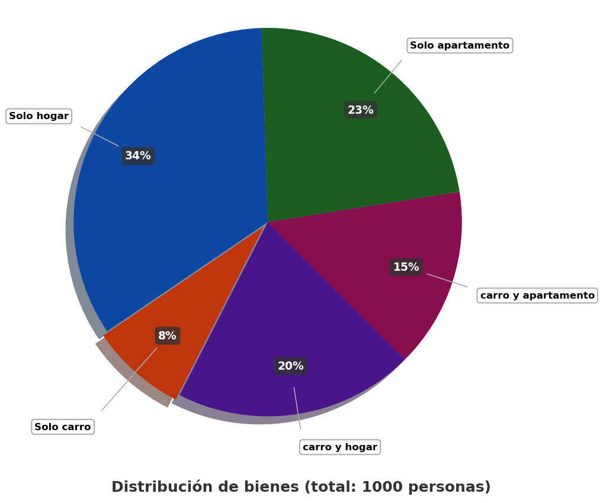

   Si 80 personas de el(la) grupo empresarial poseen solo carro, ¿cuántas personas poseen solo hogar?
   1. 180
   2. 80
   3. 340
   4. 425

#### Solution

   Para resolver este problema, necesitamos aplicar proporciones y regla de tres a partir de la información dada en el gráfico circular y el enunciado. Seguiremos un proceso paso a paso:

### Paso 1: Identificar los datos conocidos:

   - Sabemos que 80 personas poseen solo carro.
   - Según el gráfico circular, este grupo representa el 8% del total.
   - También observamos en el gráfico que las personas que poseen solo hogar representan el 34% del total.

### Paso 2: Calcular el número total de personas:

   Para encontrar el total de personas en la grupo empresarial, utilizamos la siguiente relación de proporcionalidad:

   Si 8% del total = 80 personas.

   Entonces 100% del total = X personas

   Aplicando regla de tres:

   ```
   X = (valor_conocido × 100%) ÷ porcentaje_conocido
   X = (80 × 100%) ÷ 8%
   X = (80 × 100) ÷ 8
   X = 8000 ÷ 8
   X = 1000.0000
   X = 1000 personas
   ```

   Por lo tanto, el total de personas en la grupo empresarial es 1000.

### Paso 3: Calcular el número de personas que poseen solo hogar

   Una vez conocido el total, podemos calcular cuántas personas poseen solo hogar utilizando el porcentaje correspondiente del gráfico circular:

   Si 100% del total = 1000 personas.

   Entonces 34% del total = Y personas

   Aplicando regla de tres:

   ```
   Y = (porcentaje_buscado × total_personas) ÷ 100%
   Y = (34% × 1000) ÷ 100%
   Y = (34 × 1000) ÷ 100
   Y = 34000 ÷ 100
   Y = 340.0000
   Y = 340 personas
   ```

### Paso 4: Verificación de la respuesta

   Podemos verificar nuestra respuesta comprobando que los números calculados son coherentes con los porcentajes del gráfico:
   - carro y apartamento: 150 personas (15% del total)
   - Solo apartamento: 230 personas (23% del total)
   - Solo hogar: 340 personas (34% del total)
   - Solo carro: 80 personas (8% del total)
   - carro y hogar: 200 personas (20% del total)

   La suma de todas estas categorías es 1000 personas, que coincide exactamente con nuestro total calculado de 1000 personas.

### Conclusión

   Por lo tanto, 340 personas de la grupo empresarial poseen solo hogar.
   1. Falso
   2. Falso
   3. Verdadero
   4. Falso